# Data Analysis and Visualization Using R: Lesson 1

David Robinson  
1/27/14

### How to Read These Slides

In these slides, we show blocks of R code, which are immediately followed by their output:

```r
print("hello world")
```

```
[1] "hello world"
```

The gray box shows the original R code, which you can copy and paste into your own R console to try yourself. The white box shows the code's output: you can compare it to your own results (or just trust us that that's the output).

## Numeric variables

### Assigning a variable

You store a value in a variable using the `=` operator:

```r
x = 42
```

```r
print(x)
```

```
[1] 42
```

You can also assign a variable with `<-`: this is equivalent.

```r
x <- 42
```

### Variable names

Variable names consist of letters, digits, periods and underscores (`_`), and cannot start with a digit. Convention is to use periods as spaces.

Legal variable names include:

- my.variable
- my_variable

Illegal names include:

- my-variable
- dave's.variable
- 2ndvariable

### Using R like a scientific calculator

You can perform mathematical operations using `+`, `-`, `*`, and `/`:

```r
x = 6 + 4
print(x)
```

```
[1] 10
```

```r
x / 2
```

```
[1] 5
```

```r
y = 4
x / y
```

```
[1] 2.5
```

### Using R like a scientific calculator

You can use exponentiation with `^`, or calculate the natural log:

```r
x^2
```

```
[1] 100
```

```r
y^3
```

```
[1] 64
```

```r
log(x)
```

```
[1] 2.303
```

### Assigning variables: FAQ

- What is the difference between `<-` and `=`?
  - In 99% of cases, they act exactly the same, so it's personal preference. [See here](http://stackoverflow.com/questions/1741820) to see a description of the rare cases where they differ.
- When do you need `print(x)` to display a variable, and when `x`?
  - When working in the R interactive terminal, the result of each line are displayed after being evaluated- `print` is unnecessary. When you *source* a .R file, you need `print(x)` in the line or it won't display.

### Assigning variables: FAQ

- Why is there a `[1]` before each result?
  - You'll find out in the next section!

## Vectors

You may have noticed the `[1]` at the start of each result. That's because all numbers in R are actually represented as *vectors* of length 1. The `[1]` is there to indicate rows of results.

### Vectors

For example, you can use `:` to create a long vector of consecutive integers:

```r
1:60
```

```
 [1]  1  2  3  4  5  6  7  8  9 10 11 12 13 14 15 16 17
[18] 18 19 20 21 22 23 24 25 26 27 28 29 30 31 32 33 34
[35] 35 36 37 38 39 40 41 42 43 44 45 46 47 48 49 50 51
[52] 52 53 54 55 56 57 58 59 60
```

The `[1]`, `[18]`… `[52]` at the start of each row helps keep track of the position within the vector.

### Creating and combining vectors

You can also create vectors yourself using `c`:

```r
v1 = c(1, 2, 5, 7)
v2 = c(8, 6, 3, 2)
```

You can also use `c` to combine existing vectors together:

```r
v3 = c(v1, v2)
print(v3)
```

```
[1] 1 2 5 7 8 6 3 2
```

### Extracting from vectors

Use square brackets to retrieve a value from a vector, or multiple values:

```r
v3
```

```
[1] 1 2 5 7 8 6 3 2
```

```r
v3[4]
```

```
[1] 7
```

```r
v3[4:7]
```

```
[1] 7 8 6 3
```

### Operations on vectors

Mathematical operations on a vector apply to all elements:

```r
v1 = c(1, 2, 5, 7)
v1 + 2
```

```
[1] 3 4 7 9
```

```r
v1 / 2
```

```
[1] 0.5 1.0 2.5 3.5
```

```r
sin(v1)
```

```
[1]  0.8415  0.9093 -0.9589  0.6570
```

### Operations on vectors

Similarly, you can perform operations between two vectors:

```r
v1
```

```
[1] 1 2 5 7
```

```r
v2 = c(8, 6, 3, 2)
v1 + v2
```

```
[1] 9 8 8 9
```

```r
v1 / v2
```

```
[1] 0.1250 0.3333 1.6667 3.5000
```

### Operations on vectors

You can also easily summarize a vector by calculating the sum, mean, or length:

```r
sum(v3)
```

```
[1] 34
```

```r
mean(v3)
```

```
[1] 4.25
```

```r
length(v3)
```

```
[1] 8
```

### Character vectors

Not all values you could want to store in R are numeric. You could store:

- subject names
- gene sequences
- text for analysis

We represent these as a series of characters (letters, digits, punctuation, etc).

### Assigning a character vector

Character vectors are surrounded by either single or double quotation marks.

```r
chv = "hello"
chv2 = 'hi'
chv3 = c("hello", "world")
```

Like numeric values, they are always vectors, though sometimes they are of length 1.

## Matrices

Matrices are like two-dimensional vectors, organizing values into rows and columns:

```r
m = matrix(1:9, ncol=3)
m
```

```
     [,1] [,2] [,3]
[1,]    1    4    7
[2,]    2    5    8
[3,]    3    6    9
```

### Attributes of a matrix

You can get the number of rows, the number of columns, or both:

```r
NROW(m)
```

```
[1] 3
```

```r
NCOL(m)
```

```
[1] 3
```

```r
dim(m)
```

```
[1] 3 3
```

### Retrieving a value

To extract one value from a matrix, use the structure `matrix[`**row**`,`**column**`]`.

```r
m
```

```
     [,1] [,2] [,3]
[1,]    1    4    7
[2,]    2    5    8
[3,]    3    6    9
```

```r
m[1, 3]
```

```
[1] 7
```

### Retrieving a row or column

Leaving the “row” spot or the “column” spot empty will extract, respectively, an entire column or an entire row.

```r
m[1, ]
```

```
[1] 1 4 7
```

```r
m[, 2]
```

```
[1] 4 5 6
```

### Matrix arithmetic

You can add or multiply a single value by a matrix:

```r
m + 3
```

```
     [,1] [,2] [,3]
[1,]    4    7   10
[2,]    5    8   11
[3,]    6    9   12
```

```r
m * 2
```

```
     [,1] [,2] [,3]
[1,]    2    8   14
[2,]    4   10   16
[3,]    6   12   18
```

### Transpose and diagonal

Use the `t` function to transpose a matrix:

```r
t(m)
```

```
     [,1] [,2] [,3]
[1,]    1    2    3
[2,]    4    5    6
[3,]    7    8    9
```

Use `diag` to extract the diagonal:

```r
diag(m)
```

```
[1] 1 5 9
```

### Matrix multiplication

You can also perform traditional matrix multiplication with the `%*%` operator

```r
m2 = matrix(21:32, nrow=3)
m %*% m2
```

```
     [,1] [,2] [,3] [,4]
[1,]  270  306  342  378
[2,]  336  381  426  471
[3,]  402  456  510  564
```

## Logical vectors

Another type of variable is a logical value: `TRUE` or `FALSE`. Like numbers, logical values are always stored in vectors (sometimes of length 1).

```r
x = TRUE
y = c(TRUE, FALSE, TRUE)
```

### Logical operators

Logical vectors are useful because they are the result of logical operators, such as

- `>` : greater than
- `<` : less than
- `==` : equal to
- `!=` : not equal to
- `&` : and
- `|` : or

### Logical operators: comparison

```r
x = 2  # assignment
x > 0
```

```
[1] TRUE
```

```r
x < 1
```

```
[1] FALSE
```

```r
x != 10
```

```
[1] TRUE
```

### Logical operators FAQ

- Why is the logical operator for equals `==` and not `=`?
  - Because `=` is already reserved for assignment.

## Data frames

Data frames store multiple columns of information together. Unlike a matrix, different columns in a data frame can store different kinds of information (numbers, factors, character vectors, etc)

### Built-in Datasets

R comes with built-in datasets that can be retrieved by name. You can access one with the `data` function.

```r
data(mtcars)
```

`mtcars` contains statistics about 32 cars in 1974, including miles per gallon, weight, number of cylinders, etc. Each row is one car, and each column one piece of information.

### View data frame in RStudio

```r
View(mtcars)
```

See details and documentation about the data with:

```r
?mtcars
```

or

```r
help(mtcars)
```

### See first rows of data frame

One of the most useful functions is `head`, which shows the first 6 rows of a data frame (a good way to get an idea of its contents):

```r
head(mtcars)
```

```
                   mpg cyl disp  hp drat    wt  qsec
Mazda RX4         21.0   6  160 110 3.90 2.620 16.46
Mazda RX4 Wag     21.0   6  160 110 3.90 2.875 17.02
Datsun 710        22.8   4  108  93 3.85 2.320 18.61
Hornet 4 Drive    21.4   6  258 110 3.08 3.215 19.44
Hornet Sportabout 18.7   8  360 175 3.15 3.440 17.02
Valiant           18.1   6  225 105 2.76 3.460 20.22
                  vs am gear carb
Mazda RX4          0  1    4    4
Mazda RX4 Wag      0  1    4    4
Datsun 710         1  1    4    1
Hornet 4 Drive     1  0    3    1
Hornet Sportabout  0  0    3    2
Valiant            1  0    3    1
```

### Information about a data frame

Get the number of rows, columns or both:

```r
nrow(mtcars)
```

```
[1] 32
```

```r
ncol(mtcars)
```

```
[1] 11
```

```r
dim(mtcars)
```

```
[1] 32 11
```

### Access a column by name

Use `$` to access one column by name:

```r
mtcars$mpg
```

```
 [1] 21.0 21.0 22.8 21.4 18.7 18.1 14.3 24.4 22.8 19.2
[11] 17.8 16.4 17.3 15.2 10.4 10.4 14.7 32.4 30.4 33.9
[21] 21.5 15.5 15.2 13.3 19.2 27.3 26.0 30.4 15.8 19.7
[31] 15.0 21.4
```

Each column is a vector once it is extracted.

### Access one row or value

You can use square brackets with a comma to access a single row of a data frame:

```r
mtcars[1, ]
```

```
          mpg cyl disp  hp drat   wt  qsec vs am gear
Mazda RX4  21   6  160 110  3.9 2.62 16.46  0  1    4
          carb
Mazda RX4    4
```

### Access one row or value

Or you can give `row, column` to get a single value at a particular position:

```r
mtcars[3, 2]
```

```
[1] 4
```

## Filtering a data frame

One common operation on data is to filter out rows based on some criterion.

### Subsetting rows of a data frame

You can get a set of rows using their indices:

```r
mtcars[1:2, ]
```

```
              mpg cyl disp  hp drat    wt  qsec vs am
Mazda RX4      21   6  160 110  3.9 2.620 16.46  0  1
Mazda RX4 Wag  21   6  160 110  3.9 2.875 17.02  0  1
              gear carb
Mazda RX4        4    4
Mazda RX4 Wag    4    4
```

However, what if you want “all automatic cars” or “all cars with mpg > 20”?

### Logical operators on a vector

Just like arithmetic operations, logical operators on a vector apply the test to each element individually:

```r
v = c(1, 3, 12, 5, 2, 20)
v > 4
```

```
[1] FALSE FALSE  TRUE  TRUE FALSE  TRUE
```

### Compound logical operators on a vector

You can combine them using `&` (and) or `|` (or):

```r
v > 4 & v < 15
```

```
[1] FALSE FALSE  TRUE  TRUE FALSE FALSE
```

```r
v < 6 | v > 15
```

```
[1]  TRUE  TRUE FALSE  TRUE  TRUE  TRUE
```

### Logical operations on a column

This can equally easily be applied to a column of `mtcars`:

```r
mtcars$mpg > 20
```

```
 [1]  TRUE  TRUE  TRUE  TRUE FALSE FALSE FALSE  TRUE
 [9]  TRUE FALSE FALSE FALSE FALSE FALSE FALSE FALSE
[17] FALSE  TRUE  TRUE  TRUE  TRUE FALSE FALSE FALSE
[25] FALSE  TRUE  TRUE  TRUE FALSE FALSE FALSE  TRUE
```

### Filtering a data frame logically

This logical vector can be used to subset rows of the data frame- `TRUE` means “keep the row”, `FALSE` means drop it. Place it before the comma in the square brackets:

```r
v = mtcars$mpg > 20
efficient.cars = mtcars[v, ]
```

or just:

```r
efficient.cars = mtcars[mtcars$mpg > 20, ]
```

### Filtering on multiple conditions

You can combine multiple conditions using `&` (and) or `|` (or), such as looking for automatic gearshift cars with mpg > 20:

```r
efficient.auto = mtcars[mtcars$mpg > 20 & mtcars$am == 0, ]
head(efficient.auto, 3)
```

```
                mpg cyl  disp  hp drat    wt  qsec vs
Hornet 4 Drive 21.4   6 258.0 110 3.08 3.215 19.44  1
Merc 240D      24.4   4 146.7  62 3.69 3.190 20.00  1
Merc 230       22.8   4 140.8  95 3.92 3.150 22.90  1
               am gear carb
Hornet 4 Drive  0    3    1
Merc 240D       0    4    2
Merc 230        0    4    2
```

## data.table

`data.table` is a third-party package that improves in many ways on the built-in `data.frame`.

We'll go over some of its advantages on Wednesday and Friday, but will focus on one- how it makes filtering more convenient- today.

### Turn a data.frame into a data.table

Since `data.table` is a third-party package, you need to install it first. Once it is installed, you still have to load it into R:

```r
library("data.table")
```

(You'll have to re-do that line each time you reopen R). Then convert your data.frame to a data.table:

```r
mtcars.dt = as.data.table(mtcars)
```

### Filtering a data.table

A `data.table` looks identical in many ways to a `data.frame`, but has some useful features. One is that when you're filtering, you don't need to say `mtcars$` each time when you're in the brackets- you can just refer to the column names:

```r
mtcars.dt[mpg > 20 & am == 0, ]
```

```
    mpg cyl  disp  hp drat    wt  qsec vs am gear carb
1: 21.4   6 258.0 110 3.08 3.215 19.44  1  0    3    1
2: 24.4   4 146.7  62 3.69 3.190 20.00  1  0    4    2
3: 22.8   4 140.8  95 3.92 3.150 22.90  1  0    4    2
4: 21.5   4 120.1  97 3.70 2.465 20.01  1  0    3    1
```

This doesn't mean the `mpg` and `am` variables exist: they exist only within those square brackets.

### Next Time

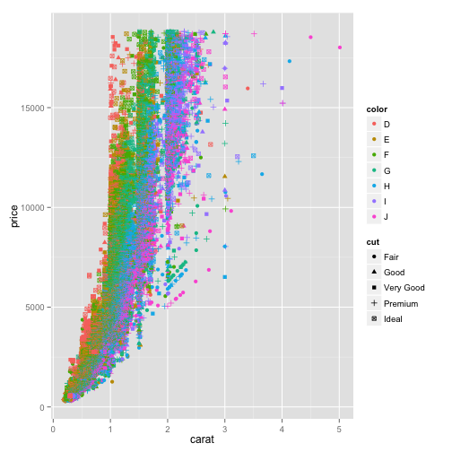

## Appendix

### About these slides

These slides were created as an [RStudio presentation](http://www.rstudio.com/ide/docs/presentations/overview), which integrates R code using [knitr](http://yihui.name/knitr/).